# Lab 8

Lauren, Ryan, Katie, Chris

3/7/2018

# Overall Question

Does a relationship exist between race (White, Black, Hispanic, Other) and leading causes of death? This question proves relevant as an exploration into if race can indicate liklihood of causes of death. For example, people think that race can act as clue to individuals risk of heart disease. Perhaps we will identify a relationship with heart disease and race within this dataset to support that claim.

This is especially interesting for our domain expert, the Census Bureau, because they are concerned with the general trends of mortality.

# Conclusion

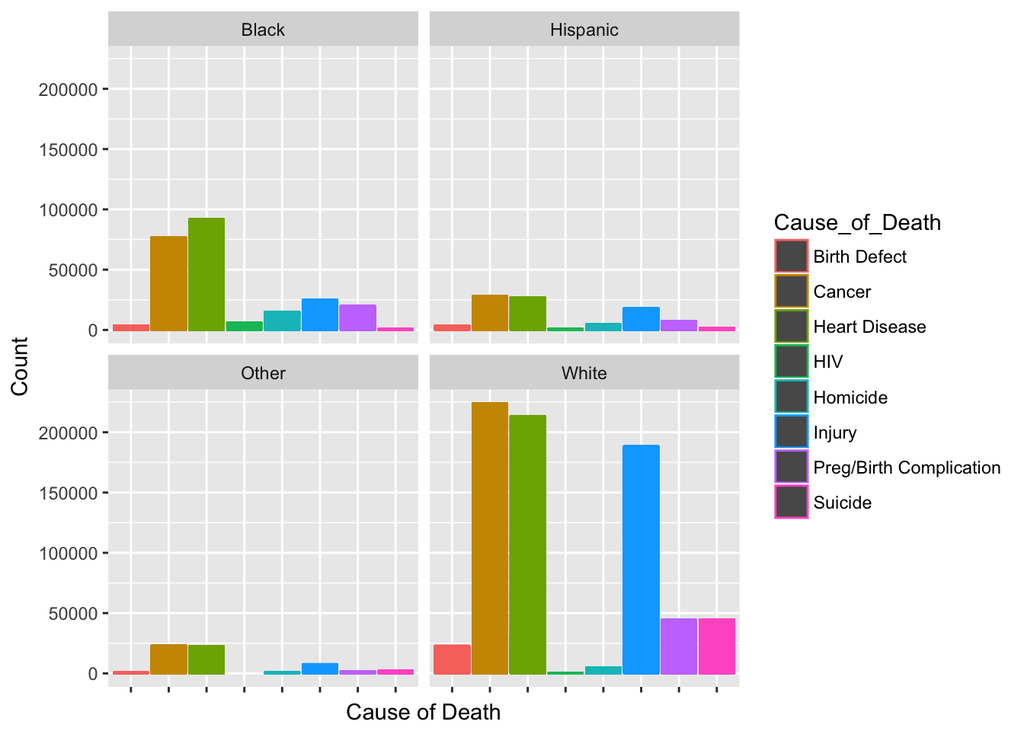

```r
ggplot(data=data2, aes(x=Cause_of_Death, y=Count, color=Cause_of_Death)) +
  geom_col()+
  facet_wrap(~Race) +
  ylab("Count") +
  xlab("Cause of Death") +
  theme(axis.text.x=element_blank())
```

## Recommendation

It seems as if across all races, the leading causes of death are primarially cancer, heart disease, and injury. There were some significant differences between each of the races. Primarially, and most easily observed, is that black people tend to die less frequently of injury than any of the other races. Also that there is a higher proportion of black people who die of homicide than any of teh other races. White people tend to die more frequently than the other races by suicide.

This information is important because it may allow targeted information about these causes of death to be sent out to relative focus groups. For example, from this dataset it is apparent that suicide prevention methods are more necessary for white people than any of the other races.

Therefore, our recommendation is this: observe the chart above (possibly normalize it by dividing by the total count for each race!), and see which races are dying more frequently of which factors. Then, using that information, create targeted health care for each race. This would provide possible antidotes to each of the most prevalent factors within the race. Hopefully this will decrease the amount of preventable deaths which are occuring, and will help educate each race based on its specific need.

# Description of the Dataset

We have decided on a very large data set found by our team member, Ryan. We are focusing on the “Leading Causes of Death” tab. This data frame has aboout 230 attributes and over 3000 observations. The attributes include county, state, and causes of death ranging from birth defect to injury to cancer.

We have tidied the data set and omitted unnecessary information. The data now has eight attributes (County Name, State Name, State Abbreviation, Cause of Death, Count, Time Span, Race, and Age Range) and 238,716 observations.

The attribute Cause of Death includes eight causes of death: pregnancy or birth complication, birth defect, injury, cancer, homicide, suicide, heart disease, and HIV. The age range is a range of ages that the data has been collected for and there are six groupings: under 1, 1-14, 15-24, 25-44, 45-64, and 65+. Race was divided into 4 groupings: white, black, hispanic, and other.

Based on the overall tidied data, for each individual, we created our own tidy data to explore our questions towards the cause of death. We selected some useful columns and combinded some datas to illustrate the tendency of the death for each state.

# Individual Findings

## Chris

base on my interesting question of the cause of leading death, the most attract question to me is the baby’s homicide and babys’ cancer stituation cause I thought it was really important to every american. toady’s baby’s death rate became a huge problem. to do that , first I need to read our team csv files, which includes plenty of variable and datas that states every countries, every states and the reason of different age range of deaths reasons.

```r
library(tidyverse)
library(tidyr)

library("ggplot2")


death<- read.csv(file="LEADINGCAUSESOFDEATH.csv")
```

what I concerned is the different states stitution and about cancer or homicide in all four race: “White”, “Black”, “others” and “hispanic” so I select the the column which include the column name that I need right below.

death1 <- select( death, CHSI_State_Name, CHSI_State_Abbr,B_Wh_Cancer, B_Bl_Cancer, B_Ot_Cancer, B_Hi_Cancer,B_Wh_Homicide, B_Bl_Homicide, B_Ot_Homicide, B_Hi_Homicide)

cause we got plenty of missing value like -1111(due to the sheet in our data set, we know -1111 means no data.), so I made all -1111 value change to “NA”

then I gather the colunm to new type which is eaier to conclude and I delete all NA rows. futhermore, to help me make the plot easier I change one of the column name “CHSI_State_Name” to “State” which would be easier to plot. Then, I got the whole new csv files death2<-death1%>%gather(‘B_Wh_Cancer’,‘B_Bl_Cancer’,‘B_Ot_Cancer’,‘B_Hi_Cancer’,‘B_Wh_Homicide’, ‘B_Bl_Homicide’, ‘B_Ot_Homicide’, ‘B_Hi_Homicide’, key=“Cause”, value=“Count”)

```r
death1 <- select( death, CHSI_State_Name, CHSI_State_Abbr,B_Wh_Cancer, B_Bl_Cancer, B_Ot_Cancer, B_Hi_Cancer,B_Wh_Homicide, B_Bl_Homicide, B_Ot_Homicide, B_Hi_Homicide)
death1[death1==-1111]<-NA
death2<-death1%>%gather('B_Wh_Cancer','B_Bl_Cancer','B_Ot_Cancer','B_Hi_Cancer','B_Wh_Homicide', 'B_Bl_Homicide', 'B_Ot_Homicide', 'B_Hi_Homicide', key="Cause", value="Count")

death2<-na.omit(death2)
names(death2)[1]<-"State"
```

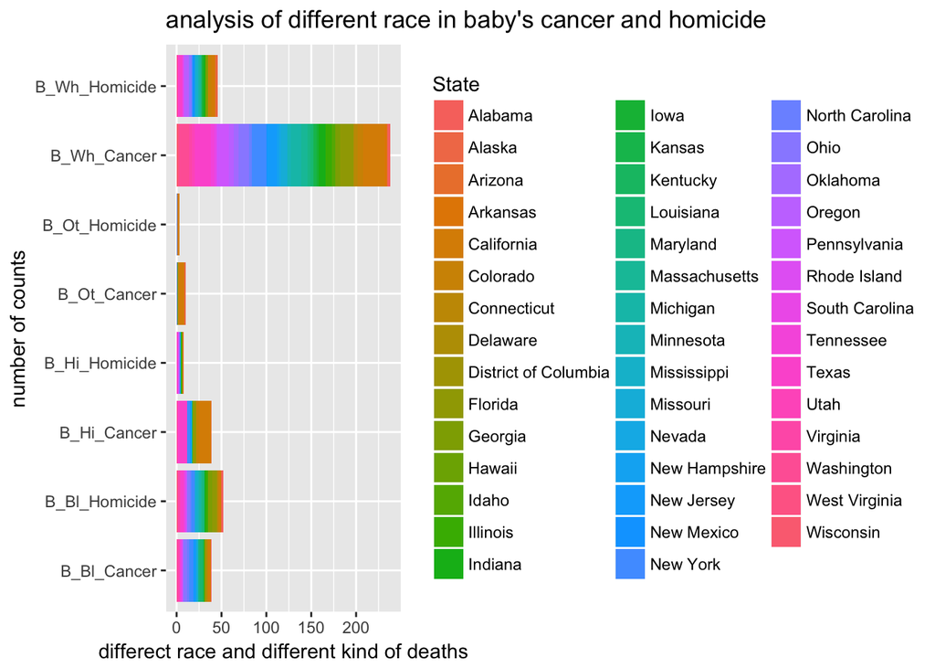

```r
ggplot(death2,aes(x=Cause))+geom_bar(aes(x=Cause,fill=State))+coord_flip()+labs(list(x="number of counts",y="differect race and different kind of deaths",title="analysis of different race in baby's cancer and homicide"))
```

Then I made the plot use geom_bar function to get the graph and filp it. Then make the labs. Then I could just analysis the graph that I made. from the plot we could conclude that although the population of different race are different, cause most of american are white. we still could see the ratio of homicide and cancer. “others” data is too small that I cannot made some conculsion, So basicly, I was thinking about white, balck and Hispanic race.

### recommendation

through the graph and the analysis that I got, we need to concern more about the cancer stitution in “White” and “Hispanic” babies maybe we spent more time to imporve our medical treatment , and we need to spent more time or money to give the black babies a safe space to grow up to avoid the homicide.

## Katie

### Question:

My interesting part is Which states of white people at age less than 1 dead due to Preg/Birth Complication have the highest death precentage? Knowing which range of age is the highest percentage death is very important. Because due to the rapid development of our country, more people not only want to improve their life quality, but hope to have a longer healthy life. And those dead childen are the youngest, they need our protection and the attentions of the society. Once we figure out the range that having highest dead chances and their reasons, we can take some actions to decrease the risk, in order to give people better lives. Hence, we want to pay more attention on why people dead, and in which range of ages people have the highest dead chances.

Based on our team tidy data, I modified some parts and made it accessible for me to explore the highest percentage of states. First, I tidied data by gathering all the white children who??s age is less than one, and selected the columns that I want to explore. Because there are several races and year, so I modified them to separate columns.And now this tidy data only contains the reasons of death for age under one year old, which is what I need.

```r
library(tidyverse)
leading<- read.csv("LEADINGCAUSESOFDEATH.csv")
data1 <- leading %>% gather('A_Wh_Comp', 'A_Bl_Comp', 'A_Ot_Comp', 'A_Hi_Comp',
                         'A_Wh_BirthDef', 'A_Bl_BirthDef', 'A_Ot_BirthDef', 'A_Hi_BirthDef',key="Cause_of_Death_For_Age_less_than_1", value = "Count") %>%mutate()

data2 <- data1 %>% select(c(CHSI_County_Name, CHSI_State_Name, CHSI_State_Abbr,
                            Cause_of_Death_For_Age_less_than_1, Count, LCD_Time_Span)) %>%mutate(Race=NA)

data2$Race <- ifelse(grepl("Wh",data2$Cause_of_Death), "White",
                     ifelse(grepl("Bl",data2$Cause_of_Death), "Black",
                            ifelse(grepl("Ot",data2$Cause_of_Death), "Other",
                                   ifelse(grepl("Hi",data2$Cause_of_Death), "Hispanic", NA)
                            )
                     )

)
```

But then I noticed that for all states the number of death and the reason spread, so I want to combine them for each state, and calculate the percentage of death reason for each state. Thus, I created a new tibble which contains the state abbreviation, the race , the death reason, the sum of dead children and the percentage that they dead.And I used the double for loops to calculate the sum and the percentage.

```r
total<-0
newda<- tibble(CHSI_State_Abbr = state.abb, Race = "White", Cause_of_death = "Preg/Birth Complication",Sum = 0,The_prob_of_death = 0)
for (j in 1:25128) {
  if(data2$Count[[j]] != -1111){
    total <- sum(data2$Count[[j]],total)
  }
}
total
```

```
## [1] 87147
```

```r
a<-1
for (i in state.abb) {
  s<- data2%>% filter(CHSI_State_Abbr==i,Cause_of_Death_For_Age_less_than_1 == "A_Wh_Comp")%>%count(n())
  #print(s)
  for (j in 1:s$n[[1]]) {
    if(data2$Count[[j]] != -1111){
      newda$Sum[[a]]<- sum(data2$Count[j],newda$Sum[[a]])
      newda$The_prob_of_death[[a]] <- sum(data2$Count[j],newda$Sum[[a]])/total

    }
  }
 a<- a+1
}
```

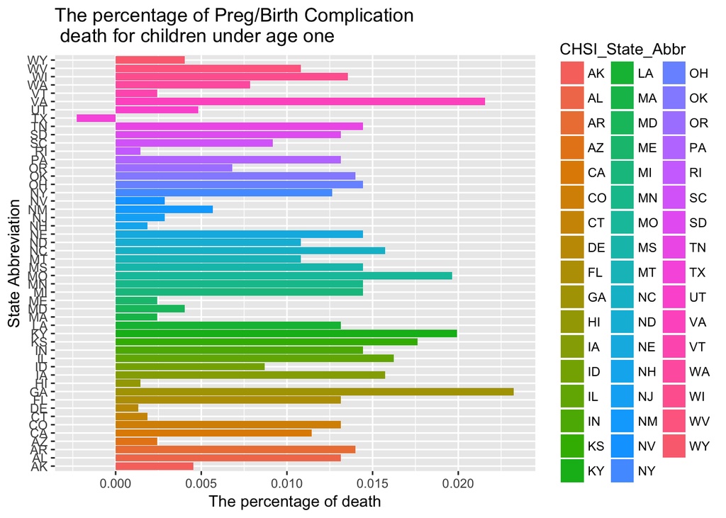

```r
ggplot(newda,mapping = aes(x = CHSI_State_Abbr, y = The_prob_of_death,fill =CHSI_State_Abbr))+
  geom_col()+
  coord_flip()+
  labs(x = "State Abbreviation", y = "The percentage of death", title = "The percentage of Preg/Birth Complication\n death for children under age one" )
```

## Ryan

I am interested in determining if there is a significant difference in the rate of these leading causes of deaths between the West Coast of the USA and the rest of the USA. I suspect that people on the west coast are slightly above the average health of the rest of the country, so I suspect that relativley fewer people will die of heart disease on the west coast compared to the rest of the country.

```r
data<- read.csv("LEADINGCAUSESOFDEATH.csv")

data[data == -1111] <- NA

tidy_data <- data%>%select(c("County_FIPS_Code","CHSI_State_Abbr","A_Wh_Comp","A_Bl_Comp","A_Ot_Comp","A_Hi_Comp","A_Wh_BirthDef","A_Bl_BirthDef","A_Ot_BirthDef","A_Hi_BirthDef","B_Wh_Injury","B_Bl_Injury","B_Ot_Injury","B_Hi_Injury","B_Wh_Cancer","B_Bl_Cancer","B_Ot_Cancer","B_Hi_Cancer","B_Wh_Homicide","B_Bl_Homicide","B_Ot_Homicide","B_Hi_Homicide","C_Wh_Injury","C_Bl_Injury","C_Ot_Injury","C_Hi_Injury","C_Wh_Homicide","C_Bl_Homicide","C_Ot_homicide","C_Hi_Homicide","C_Wh_Suicide","C_Bl_Suicide","C_Ot_Suicide","C_Hi_Suicide","C_Wh_Cancer","C_Bl_Cancer","C_Ot_Cancer","C_Hi_Cancer","D_Wh_Injury","D_Bl_Injury","D_Ot_Injury","D_Hi_Injury","D_Wh_Cancer","D_Bl_Cancer","D_Ot_Cancer","D_Hi_Cancer","D_Wh_HeartDis","D_Bl_HeartDis","D_Ot_HeartDis","D_Hi_HeartDis","D_Wh_Suicide","D_Bl_Suicide","D_Ot_Suicide","D_Hi_Suicide","D_Wh_HIV","D_Bl_HIV","D_Ot_HIV","D_Hi_HIV","D_Wh_Homicide","D_Bl_Homicide","D_Ot_Homicide","D_Hi_Homicide","E_Wh_Cancer","E_Bl_Cancer","E_Ot_Cancer","E_Hi_Cancer","E_Wh_HeartDis","E_Bl_HeartDis","E_Ot_HeartDis","E_Hi_HeartDis","F_Wh_HeartDis","F_Bl_HeartDis","F_Ot_HeartDis","F_Hi_HeartDis","F_Wh_Cancer","F_Bl_Cancer","F_Ot_Cancer","F_Hi_Cancer"))

tidy_data<-tidy_data%>%gather("A_Wh_Comp","A_Bl_Comp","A_Ot_Comp","A_Hi_Comp","A_Wh_BirthDef","A_Bl_BirthDef","A_Ot_BirthDef","A_Hi_BirthDef","B_Wh_Injury","B_Bl_Injury","B_Ot_Injury","B_Hi_Injury","B_Wh_Cancer","B_Bl_Cancer","B_Ot_Cancer","B_Hi_Cancer","B_Wh_Homicide","B_Bl_Homicide","B_Ot_Homicide","B_Hi_Homicide","C_Wh_Injury","C_Bl_Injury","C_Ot_Injury","C_Hi_Injury","C_Wh_Homicide","C_Bl_Homicide","C_Ot_homicide","C_Hi_Homicide","C_Wh_Suicide","C_Bl_Suicide","C_Ot_Suicide","C_Hi_Suicide","C_Wh_Cancer","C_Bl_Cancer","C_Ot_Cancer","C_Hi_Cancer","D_Wh_Injury","D_Bl_Injury","D_Ot_Injury","D_Hi_Injury","D_Wh_Cancer","D_Bl_Cancer","D_Ot_Cancer","D_Hi_Cancer","D_Wh_HeartDis","D_Bl_HeartDis","D_Ot_HeartDis","D_Hi_HeartDis","D_Wh_Suicide","D_Bl_Suicide","D_Ot_Suicide","D_Hi_Suicide","D_Wh_HIV","D_Bl_HIV","D_Ot_HIV","D_Hi_HIV","D_Wh_Homicide","D_Bl_Homicide","D_Ot_Homicide","D_Hi_Homicide","E_Wh_Cancer","E_Bl_Cancer","E_Ot_Cancer","E_Hi_Cancer","E_Wh_HeartDis","E_Bl_HeartDis","E_Ot_HeartDis","E_Hi_HeartDis","F_Wh_HeartDis","F_Bl_HeartDis","F_Ot_HeartDis","F_Hi_HeartDis","F_Wh_Cancer","F_Bl_Cancer","F_Ot_Cancer","F_Hi_Cancer",key = "COD",value = "Count")







data2 <- tidy_data %>% select(c(County_FIPS_Code, CHSI_State_Abbr,
                        COD, Count)) %>%
  mutate(Race=NA) %>%
  mutate(Age_Range=NA)
head(data2)
```

```
##   County_FIPS_Code CHSI_State_Abbr       COD Count Race Age_Range
## 1                1              AL A_Wh_Comp    NA   NA        NA
## 2                3              AL A_Wh_Comp    57   NA        NA
## 3                5              AL A_Wh_Comp    NA   NA        NA
## 4                7              AL A_Wh_Comp    NA   NA        NA
## 5                9              AL A_Wh_Comp    34   NA        NA
## 6               11              AL A_Wh_Comp    NA   NA        NA
```

```r
data2$COD <- ifelse(grepl('Comp',data2$COD), "Preg/Birth Complication",
                          ifelse(grepl('BirthDef',data2$COD), "Birth Defect",
                            ifelse(grepl('Injury',data2$COD), "Injury",
                              ifelse(grepl('Cancer',data2$COD), "Cancer",
                                ifelse(grepl('omicide',data2$COD), "Homicide",
                                  ifelse(grepl('Suicide',data2$COD), "Suicide",
                                    ifelse(grepl('HeartDis',data2$COD), "Heart Disease",
                                      ifelse(grepl('HIV',data2$COD), "HIV", NA
                                            )
                                          )
                                        )
                                      )
                                    )
                                  )
                                )
                               )





data2$Age_Range <- ifelse(grepl("A_",data2$COD), "under 1",
                          ifelse(grepl("B_",data2$COD), "1-14",
                                 ifelse(grepl("C_",data2$COD), "15-24",
                                        ifelse(grepl("D_",data2$COD), "25-44",
                                               ifelse(grepl("E_",data2$COD), "45-64",
                                                      ifelse(grepl("F_",data2$COD), "65+", data2$COD)
                                                      )
                                               )
                                        )
                                )
                          )


data_West_Coast <- data2 %>% filter(CHSI_State_Abbr == "CA" | CHSI_State_Abbr == "OR"| CHSI_State_Abbr == "WA")
```

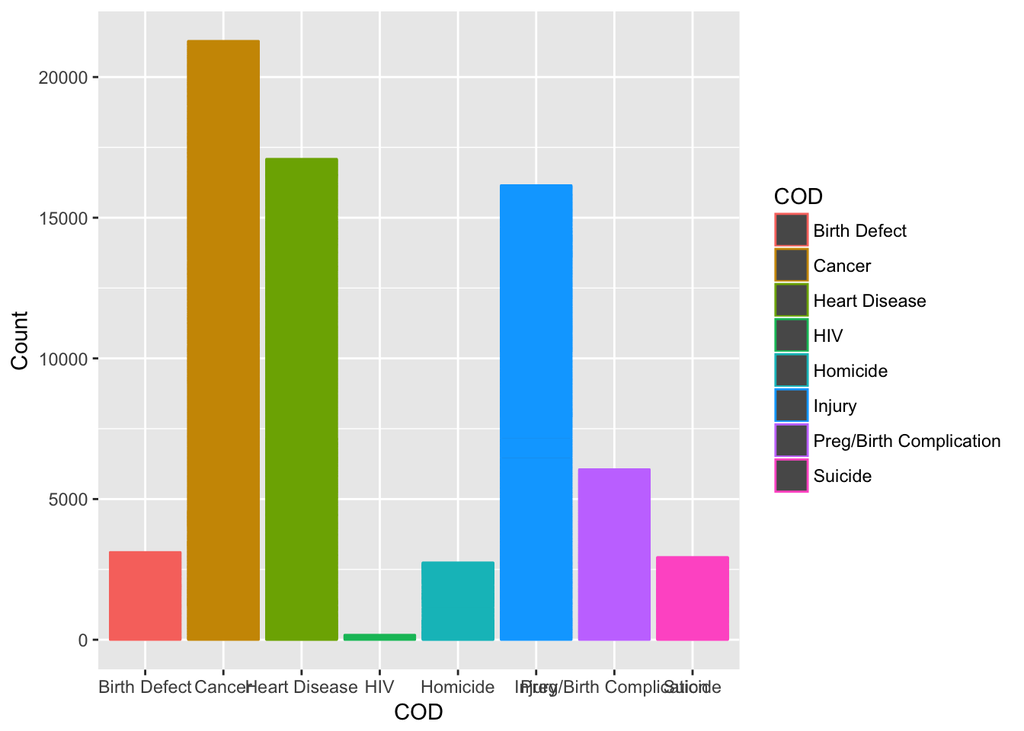

```r
ggplot(data_West_Coast, aes(x=COD, y=Count, color=COD)) +
  geom_col()
```

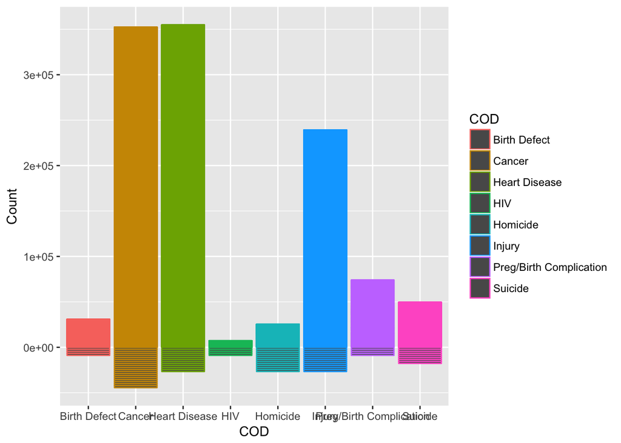

```r
ggplot(data2, aes(x=COD, y=Count, color=COD)) +
  geom_col()
```

I was interested in looking at the differences in the leading causes of death on the West Coast versus for the country as a whole. It seems as if the causes of death are generally similar, however, on the west coast, there seems to be slightly less heart disease and slightly more homocides than compared to the rest of the country (relative to other causes of death).

## Lauren

I am interested in comparing causes of death in Illinois to causes of death in Colorado. Being from Illinois, and now living in Colorado, I recognize how different the lifestyles are in each state. Even just what people buy at the grocery stores tells me that Colorado is a much healthier state than Illinois. I want to see if this intuition is reflected in leading causes of death. For example, I would expect to find more outdoor accidents leading to death in Colorado because it is a much more active state than Illinois. This becomes interesting on a larger scale because Colorado is known as one of the least-obese states and has the most physcial activity. Considering leading causes of deaths in the healthiest state could result in some more insights into the definition of “healthy”.

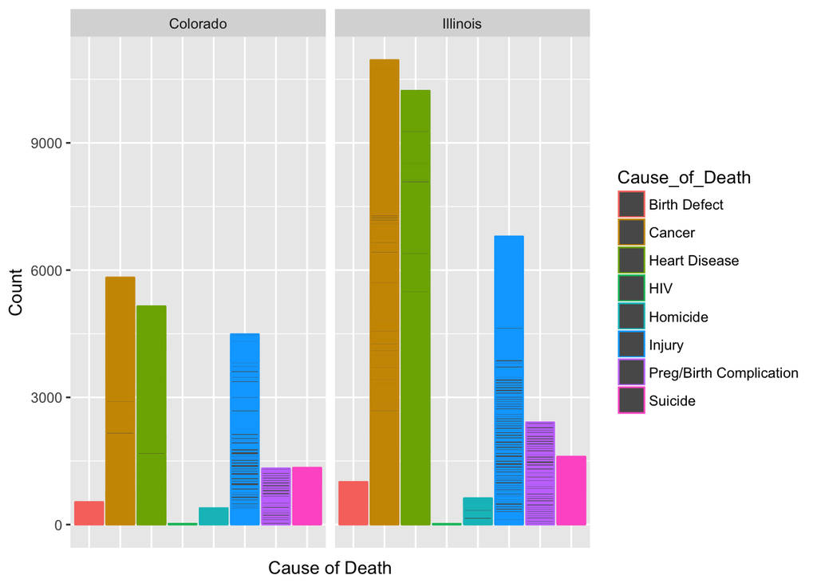

```r
ggplot(data=data_IL_CO, aes(x=Cause_of_Death, y=Count, color=Cause_of_Death)) +
  geom_col()+
  facet_wrap(~CHSI_State_Name) +
  theme(axis.text.x=element_blank(), axis.ticks.x=element_blank()) +
  xlab("Cause of Death")
```

I first considered just comparing the two states. It would be better to normalize the data relative to the states in order to have a cleaner comparison. However, it appears the Illinoisans tend ot suffer more from cancer and heart disease than Coloradoans. After seeing this plot, I figured I should probably consider age as well.

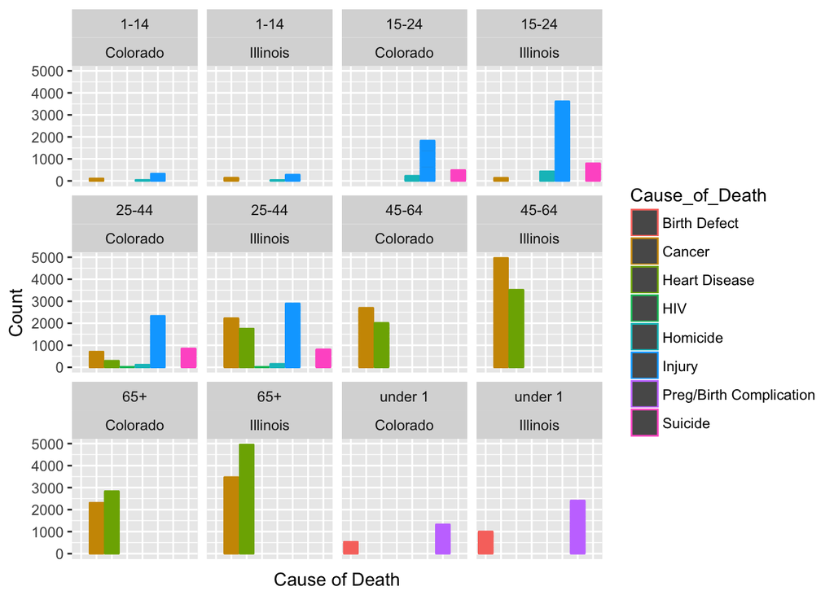

```r
ggplot(data=data_IL_CO, aes(x=Cause_of_Death, y=Count, color=Cause_of_Death)) +
  geom_col()+
  facet_wrap(Age_Range~CHSI_State_Name)+
  theme(axis.text.x=element_blank(), axis.ticks.x=element_blank()) +
  xlab("Cause of Death")
```

Even at each age group, we see a similar pattern as before. I would not want to make any finalized conclusions until the counts were normalized by state, but it does appear that Colorado may be more healthy than Illinois based on the mortality counts caused by cancer and heart disease.

# Who Did What

## Chris

I tried to analysis the own aspect that I am interesting and I tidy my data set in my own easy data set which only include 435 obs of 4 variables, than I try to find the conclusion and the analysis of the casue of deaths in baby which only concern about the “cancer” and “homicide”

## Katie

I modified our main question and the description of our tidied data-set. Adding some specific points and more explanations to the tidy data based on my tidy data. In my individual part, I first gathered all data about dead children under age one, and selected columns for each state. Then in order to show the percentage for each state, I calculated the number of children doe to same death reason and divided by the total number to get the percentage. Because the bar chart is obvious to show the percentage, I indicated the numbers into the bar chart.

## Lauren

I outlined our R document, helped write our the “Overall Question” section, and assisted in the “Description of the Dataset” section. I also played a large role in the conclusion visualizations and the first East Africa Lake data visualization.

When tidying the data, I knew the most important function I needed to use was gather(). Using the pipe, I gathered each of the causes of death into a Cause_of_Death column and a Count column. I then realized that we really did not need the confidence intervals that were associated with each cause of death, so I used select() within the pipe so my data would only include the following attributes: HSI_County_Name, CHSI_State_Name, CHSI_State_Abbr, Cause_of_Death, Count, and LCD_Time_Span. I made this decision because our overall question, and my individual question, did not require these attributes.

Race and Age Range were hidden within the Cause_of_Death attributes. I knew these were attributes and a tidy dataset has a column for each attribute. I used mutate to establish a Race attribute and an Age Range attribute both filled with NA values. I decided the easiest way for me to extract the race and age data from Cause_of_Death was to use the ifelse() function with grepl() function in order to compare a substring to the Cause_of_Death string value. For example, an original observation for cause of death was A_Wh_BirthDef. I wrote the code so it would identify pieces of that observation. If the string contains “A_”, then change the associated age range to “under 1”. If the string contains “Wh”, change the associated race to “White”. Finally, if the string contains “BirthDef”, change Cause_of_Death to “Birth Defect”.

# Team Exercise Plot (East Africa Lake Data)

We are attemping to combine data from four data sets. The common variable across all for data sets is year. We first must consider which range of years has the most data.

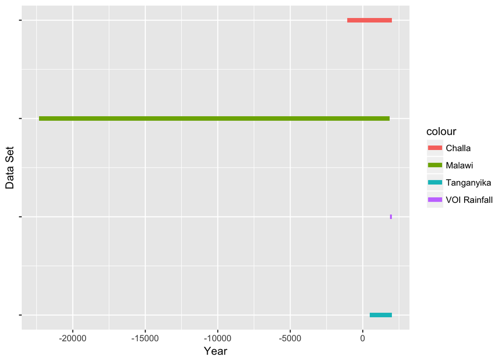

```r
ggplot() +
  geom_segment(data = dataR, mapping= aes(x=min(year), y =1, xend=max(year), yend=1, color="Tanganyika"), size=2) +
  geom_segment(data = dataL, mapping= aes(x=min(Year), y =2, xend=max(Year), yend=2, color="VOI Rainfall"), size=2) +
  geom_segment(data = dataK, mapping= aes(x=min(Year), y =3, xend=max(Year), yend=3, color="Malawi"), size=2) +
  geom_segment(data = dataC, mapping= aes(x=min(na.omit(as.numeric(`Age AD`))), y =4,
                                xend=max(na.omit(as.numeric(`Age AD`))), yend=4, color="Challa"), size=2) +
  theme(axis.text.y=element_blank()) +
  labs(x="Year", y="Data Set")
```

The above plot shows we have alot of data between year 1900 to 2006. Unfortunately, in order to consider this data we must drop the information from the Malawi data set.

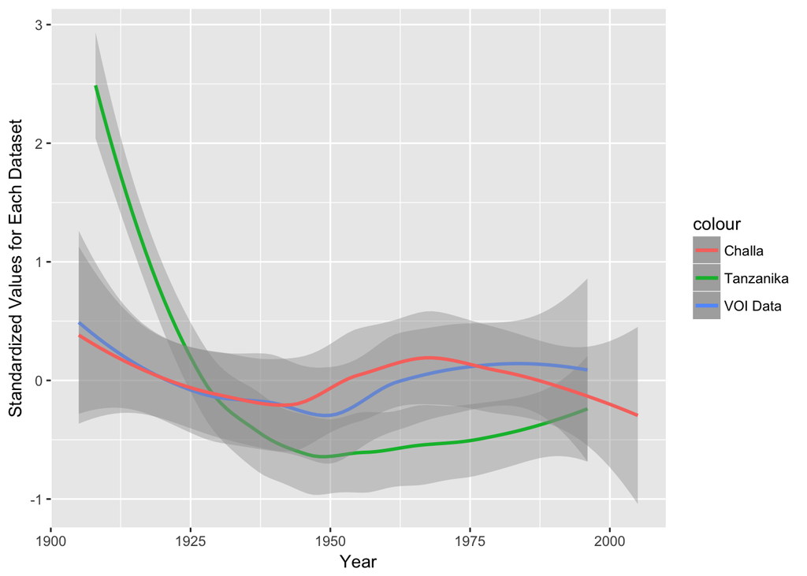

```r
ggplot()+
  geom_smooth(aes(x = ryan_std$year,y = ryan_std[ ,5],color = "Tanzanika"))+
  geom_smooth(aes(x = lauren_std$Year,y = lauren_std[ ,3],color ="VOI Data"))+
  geom_smooth(aes(x = challa_std$Year,y = challa_std$std,color="Challa")) +
  xlab("Year") +
  ylab("Standardized Values for Each Dataset")
```

This plot compares a smoothed estimate of the data from the three lake datasets: Tanzanika, VOI Data, and Challa.